# Models and smoking variables

Andrey Ziyatdinov

2017-07-06

# 1 About

Michael: Alternative modeling to `SmokCigNow` + `Packs_Year` (descriptions/phen/03-meeting-Michael.md)

- `Duration_Smoking` + `log_CigPerDaySmokAvg` = `Packs_Year`
- `CigPerDaySmokNow` (cont.) = `SmokCigNow` (binary)
- Difference in the number of parameters: `2 + 1 = 3`

# 2 Summary

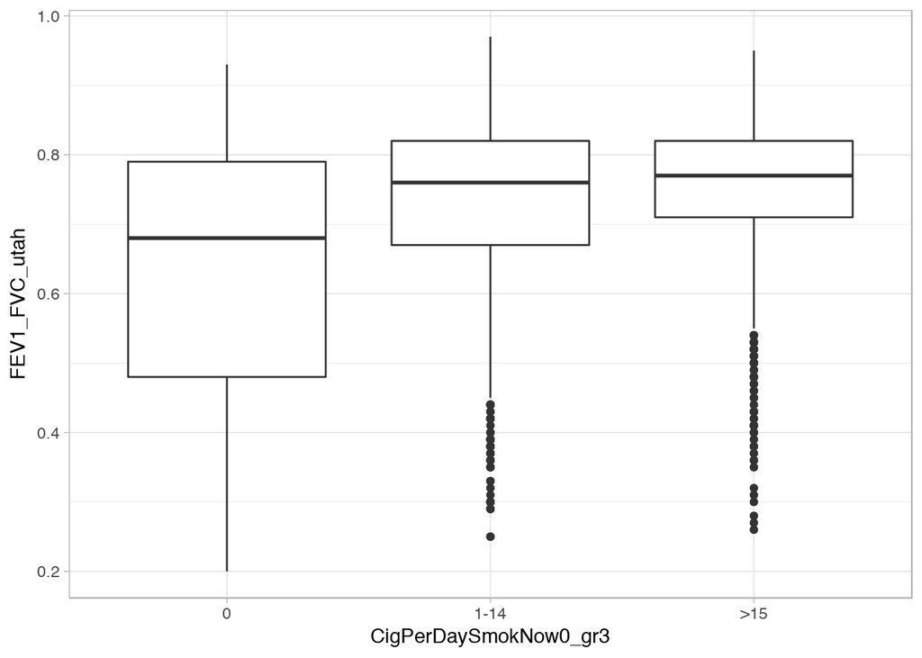

```r
phen %$% CigPerDaySmokNow0_gr3 %>% table
```

```
.
   0 1-14  >15
 657 1261 1382
```

```r
phen %$% CigPerDaySmokNow0_gr3 %>% table %>% prop.table %>% round(2)
```

```
.
   0 1-14  >15
0.20 0.38 0.42
```

## 2.1 Previous vs. Current model

| Type of change | Previous Model | Current Model | Diff. in param. |
| --- | --- | --- | --- |
| Fixed effects | `ATS_PackYears` | `Duration_Smoking + log_CigPerDaySmokAvg` | 1 |
| Fixed effects | `SmokCigNowRev` | `CigPerDaySmokNow0_gr3` | 1 |
| Residual random effect | `(SmokCigNowRev\|rsid)` | `(CigPerDaySmokNow0Rev_gr3\|rsid)` | 1 |
| Fixed effects |  | `SmokCigarNow` | 1 |

```r
with(phen, table(SmokCigNow, SmokCigarNow))
```

```
          SmokCigarNow
SmokCigNow    0    1
         0  649    8
         1 2540   99
```

### 2.1.1 Improvement in terms of LRT

| trait | comparison | Chisq | df | pval |
| --- | --- | --- | --- | --- |
| FEV1pp_utah | LRT: Previous vs Current | 107.76026 | 4 | 2.185604e-22 |
| FVCpp_utah | LRT: Previous vs Current | 63.34490 | 4 | 5.741303e-13 |
| FEV1_FVC_utah | LRT: Previous vs Current | 61.96257 | 4 | 1.121747e-12 |
| TLCpp_race_adjusted | LRT: Previous vs Current | 60.82450 | 4 | 1.946375e-12 |
| FEV1_utah | LRT: Previous vs Current | 56.89823 | 4 | 1.299506e-11 |
| log_pctEmph_Slicer | LRT: Previous vs Current | 52.10764 | 4 | 1.309780e-10 |
| FVC_utah | LRT: Previous vs Current | 10.87156 | 4 | 2.804610e-02 |

### 2.1.2 Improvement in terms of R-squared

Previous models proposed before this report:

- Model 0: the initial model, where the residual matrix as in OLS
- Model 1: `smk0` model, where the residual matrix is for 2 groups as in WLS

Current models proposed in this report:

- Model 2: the residual matrix is for 3 groups as in WLS
- Model 3: new covariates, but the residual matrix is for 2 groups as in WLS
- Model 4: both updates
  - the residual matrix is for 3 groups as in WLS (random effects)
  - new covariates (fixed effecs)

Function used to compute R2 for mixed models (http://glmm.wikidot.com/faq):

```
function(m)
{
   lmfit <-  lm(model.response(model.frame(m)) ~ fitted(m))
   summary(lmfit)$r.squared
}
```

| trait | R2_0 | R2_1 | R2_2 | R2_3 | R2_4 | Rel_0_1_smk0 | Rel_1_2_rand | Rel_1_3_fixed | Rel_1_4_both | Rel_overall |
| --- | --- | --- | --- | --- | --- | --- | --- | --- | --- | --- |
| FVCpp_utah | 0.11 | 0.26 | 0.41 | 0.26 | 0.41 | 2.46 | 1.56 | 1.00 | 1.53 | 3.77 |
| TLCpp_race_adjusted | 0.08 | 0.23 | 0.32 | 0.22 | 0.32 | 2.89 | 1.39 | 0.99 | 1.40 | 4.04 |
| FEV1pp_utah | 0.19 | 0.38 | 0.52 | 0.39 | 0.51 | 2.00 | 1.34 | 1.02 | 1.34 | 2.68 |
| FEV1_FVC_utah | 0.24 | 0.50 | 0.65 | 0.50 | 0.66 | 2.08 | 1.32 | 1.02 | 1.33 | 2.76 |
| log_pctEmph_Slicer | 0.35 | 0.46 | 0.54 | 0.47 | 0.54 | 1.33 | 1.18 | 1.01 | 1.18 | 1.56 |
| FEV1_utah | 0.50 | 0.59 | 0.63 | 0.60 | 0.63 | 1.18 | 1.06 | 1.01 | 1.06 | 1.25 |
| FVC_utah | 0.57 | 0.62 | 0.63 | 0.62 | 0.63 | 1.08 | 1.02 | 1.00 | 1.02 | 1.10 |

## 2.2 Impact of `ATS_PackYears` replacement

| trait | comparison | Chisq | df | pval |
| --- | --- | --- | --- | --- |
| FEV1pp_utah | LRT: Pks vs Dur + CigAvr | 18.3141188 | 1 | 1.873138e-05 |
| TLCpp_race_adjusted | LRT: Pks vs Dur + CigAvr | 14.0404926 | 1 | 1.789161e-04 |
| FEV1_utah | LRT: Pks vs Dur + CigAvr | 13.4902419 | 1 | 2.398073e-04 |
| FVCpp_utah | LRT: Pks vs Dur + CigAvr | 8.0812916 | 1 | 4.472456e-03 |
| log_pctEmph_Slicer | LRT: Pks vs Dur + CigAvr | 7.9390834 | 1 | 4.837833e-03 |
| FEV1_FVC_utah | LRT: Pks vs Dur + CigAvr | 5.0444212 | 1 | 2.470536e-02 |
| FVC_utah | LRT: Pks vs Dur + CigAvr | 0.7261949 | 1 | 3.941194e-01 |

## 2.3 Impact of `SmokCigNow` replacement

| trait | comparison | Chisq | df | pval |
| --- | --- | --- | --- | --- |
| FEV1_FVC_utah | LRT: CigNow vs CigNowGr3 | 25.925478 | 1 | 3.548546e-07 |
| FEV1pp_utah | LRT: CigNow vs CigNowGr3 | 23.267762 | 1 | 1.409427e-06 |
| log_pctEmph_Slicer | LRT: CigNow vs CigNowGr3 | 20.209816 | 1 | 6.939591e-06 |
| FEV1_utah | LRT: CigNow vs CigNowGr3 | 19.960747 | 1 | 7.904839e-06 |
| FVCpp_utah | LRT: CigNow vs CigNowGr3 | 5.075095 | 1 | 2.427195e-02 |
| TLCpp_race_adjusted | LRT: CigNow vs CigNowGr3 | 4.913216 | 1 | 2.665197e-02 |
| FVC_utah | LRT: CigNow vs CigNowGr3 | 1.216350 | 1 | 2.700782e-01 |

## 2.4 Impact of adding `SmokCigarNow`

| trait | comparison | Chisq | df | pval |
| --- | --- | --- | --- | --- |
| FEV1pp_utah | LRT: adding SmokCigarNow | 52.247581 | 1 | 4.892618e-13 |
| FVCpp_utah | LRT: adding SmokCigarNow | 41.974687 | 1 | 9.246264e-11 |
| TLCpp_race_adjusted | LRT: adding SmokCigarNow | 39.658444 | 1 | 3.024940e-10 |
| FEV1_utah | LRT: adding SmokCigarNow | 18.236554 | 1 | 1.950983e-05 |
| log_pctEmph_Slicer | LRT: adding SmokCigarNow | 14.362082 | 1 | 1.508088e-04 |
| FVC_utah | LRT: adding SmokCigarNow | 7.564294 | 1 | 5.953597e-03 |
| FEV1_FVC_utah | LRT: adding SmokCigarNow | -1.541672 | 1 | 1.000000e+00 |

## 2.5 Impact of 3 groups in residual variance

| trait | comparison | Chisq | df | pval |
| --- | --- | --- | --- | --- |
| FEV1_FVC_utah | LRT: 2 vs 3 sds | 30.7942222 | 1 | 2.868908e-08 |
| FEV1pp_utah | LRT: 2 vs 3 sds | 11.1303165 | 1 | 8.492810e-04 |
| FVCpp_utah | LRT: 2 vs 3 sds | 7.2585004 | 1 | 7.056619e-03 |
| log_pctEmph_Slicer | LRT: 2 vs 3 sds | 5.2558573 | 1 | 2.187302e-02 |
| FEV1_utah | LRT: 2 vs 3 sds | 2.5197859 | 1 | 1.124258e-01 |
| TLCpp_race_adjusted | LRT: 2 vs 3 sds | 2.1485106 | 1 | 1.427083e-01 |
| FVC_utah | LRT: 2 vs 3 sds | 0.3250399 | 1 | 5.685945e-01 |

# 3 Experimental code with examples

## 3.1 `Duration_Smoking + log_CigPerDaySmokAvg` vs. `Packs_Year`

- Model 1: `. ~ . + ATS_PackYears`
- Model 2: `. ~ . + Duration_Smoking + log_CigPerDaySmokAvg`

| trait | comparison | Chisq | pval |
| --- | --- | --- | --- |
| FEV1_utah | Packs vs Dur + CigAvr | 19.529639 | 9.905084e-06 |
| FEV1pp_utah | Packs vs Dur + CigAvr | 16.954273 | 3.829104e-05 |
| log_pctEmph_Slicer | Packs vs Dur + CigAvr | 13.522367 | 2.357369e-04 |
| FEV1_FVC_utah | Packs vs Dur + CigAvr | 12.150513 | 4.907437e-04 |
| TLCpp_race_adjusted | Packs vs Dur + CigAvr | 10.701739 | 1.070349e-03 |
| FVCpp_utah | Packs vs Dur + CigAvr | 5.663098 | 1.732549e-02 |
| FVC_utah | Packs vs Dur + CigAvr | 5.136779 | 2.342406e-02 |

## 3.2 Improving by adding `Packs_Year`?

- Model 1: `. ~ . + Duration_Smoking + log_CigPerDaySmokAvg`
- Model 2: `. ~ . + Duration_Smoking + log_CigPerDaySmokAvg + ATS_PackYears`

| trait | comparison | Chisq | pval |
| --- | --- | --- | --- |
| FEV1_FVC_utah | Dur + CigAvr vs Dur + CigAvr + Packs | 1.72863367 | 0.1885855 |
| log_pctEmph_Slicer | Dur + CigAvr vs Dur + CigAvr + Packs | 1.67345971 | 0.1957958 |
| FEV1_utah | Dur + CigAvr vs Dur + CigAvr + Packs | 0.55230310 | 0.4573782 |
| FEV1pp_utah | Dur + CigAvr vs Dur + CigAvr + Packs | 0.45705331 | 0.4990043 |
| TLCpp_race_adjusted | Dur + CigAvr vs Dur + CigAvr + Packs | 0.18275138 | 0.6690193 |
| FVC_utah | Dur + CigAvr vs Dur + CigAvr + Packs | 0.10867392 | 0.7416589 |
| FVCpp_utah | Dur + CigAvr vs Dur + CigAvr + Packs | 0.07484763 | 0.7844051 |

## 3.3 `CigPerDaySmokNow_gr`

http://www.nhs.uk/news/2012/12December/Pages/Just-a-single-cigarette-a-day-linked-to-sudden-death.aspx

- 1-14 cigarettes per day
- 15-24 cigarettes per day
- greater than or equal to 25 cigarettes per day

### 3.3.1 Missing values in CigPerDaySmokNow

```
SmokCigNow FALSE TRUE
         0    60  597
         1  2636    7
```

```
          CigPerDaySmokNow0_gr4
SmokCigNow    0 1-14 15-24  >25 <NA>
         0  657    0     0    0    0
         1    0 1259   929  448    7
```

### 3.3.2 Boxplots

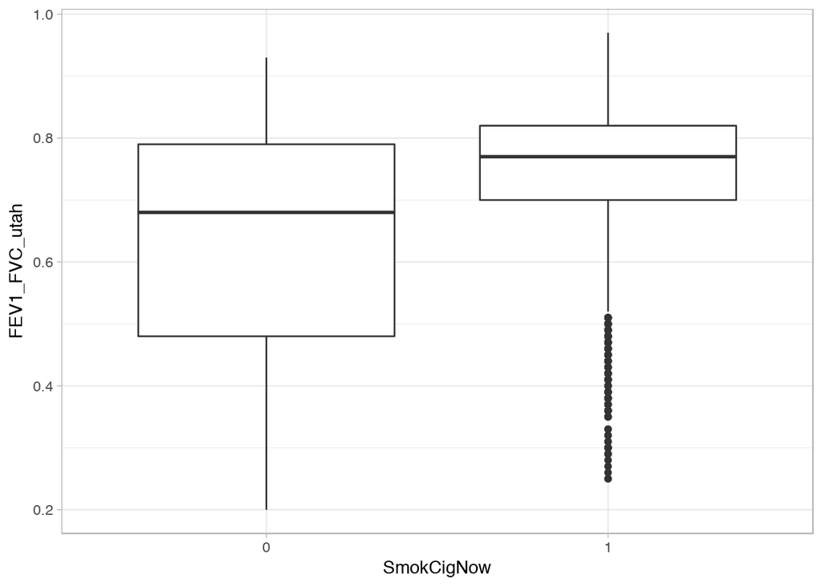

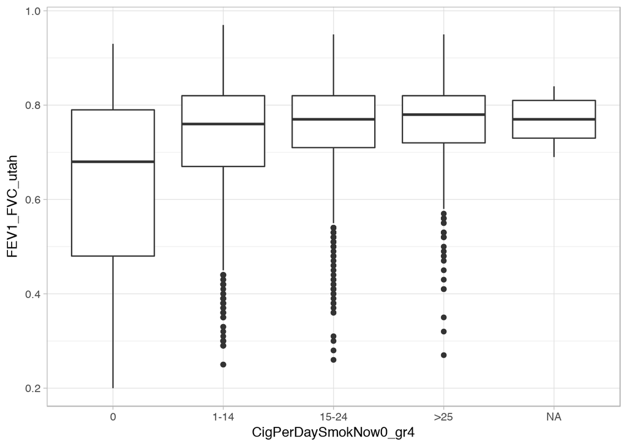

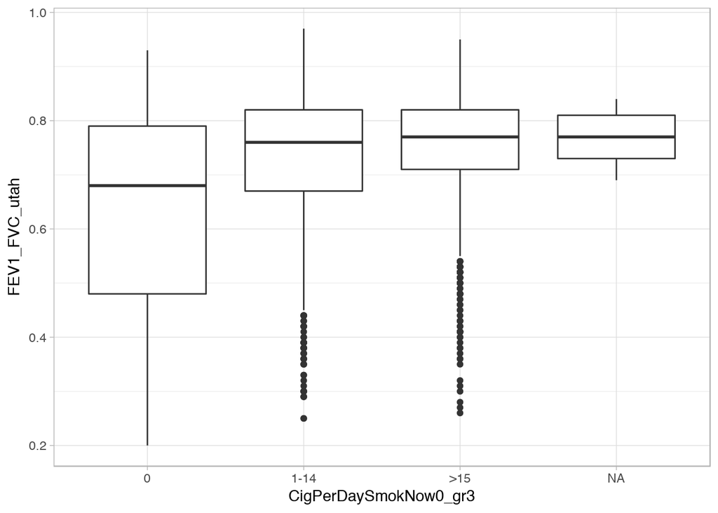

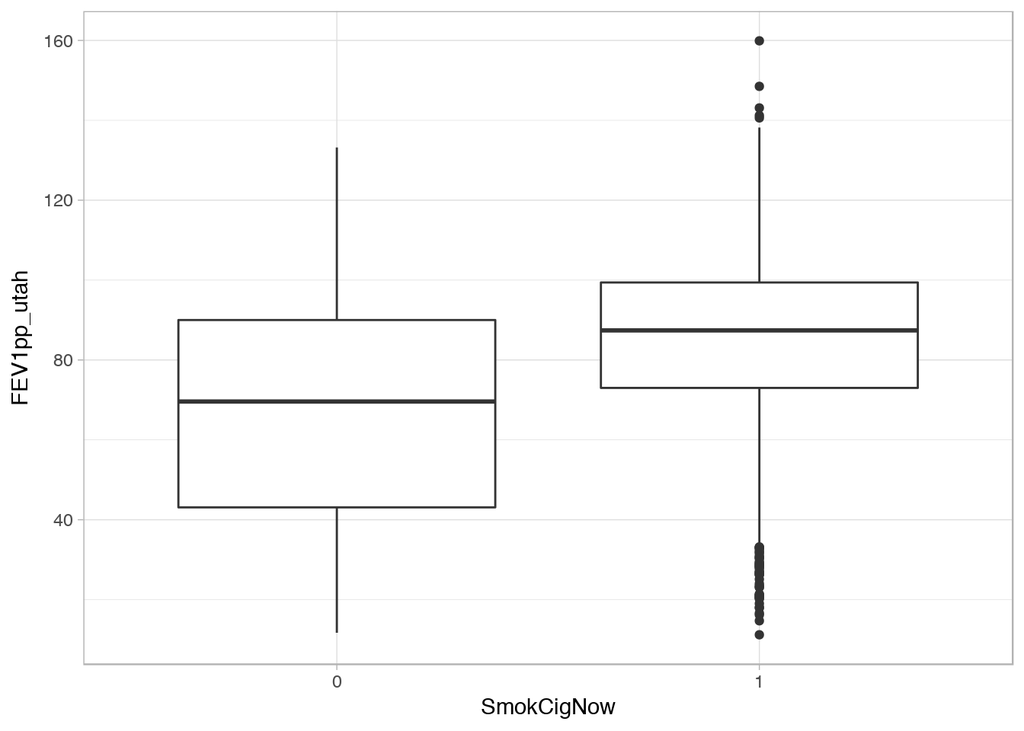

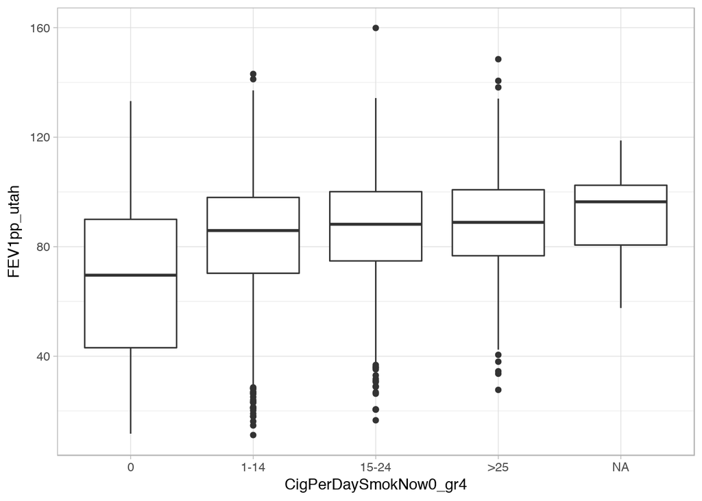

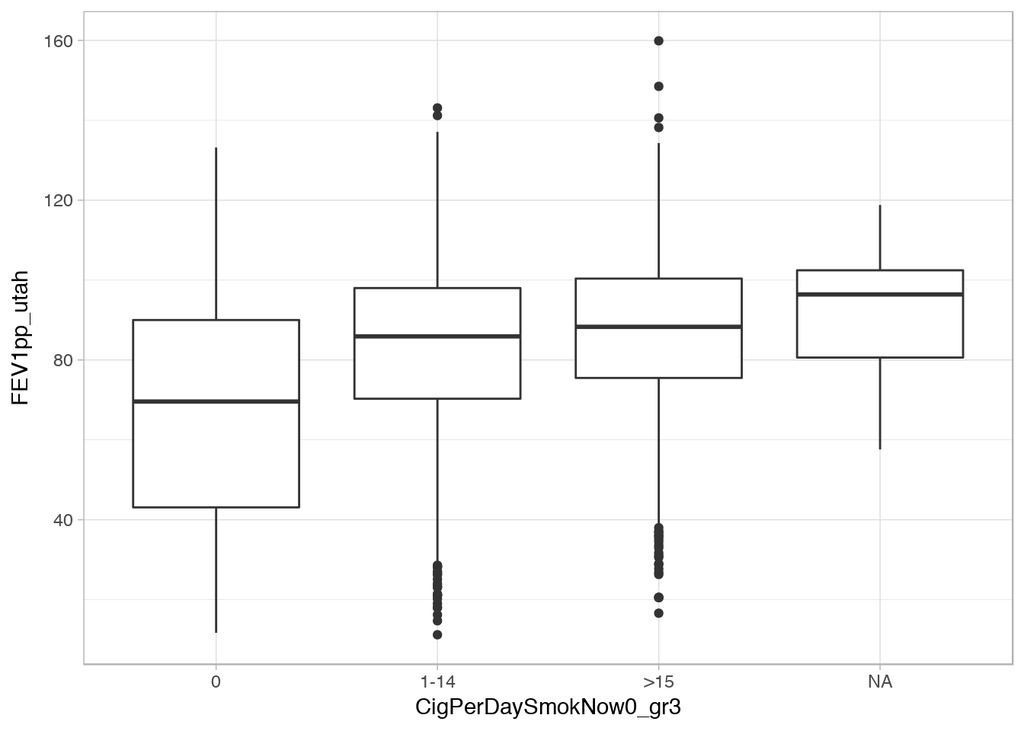

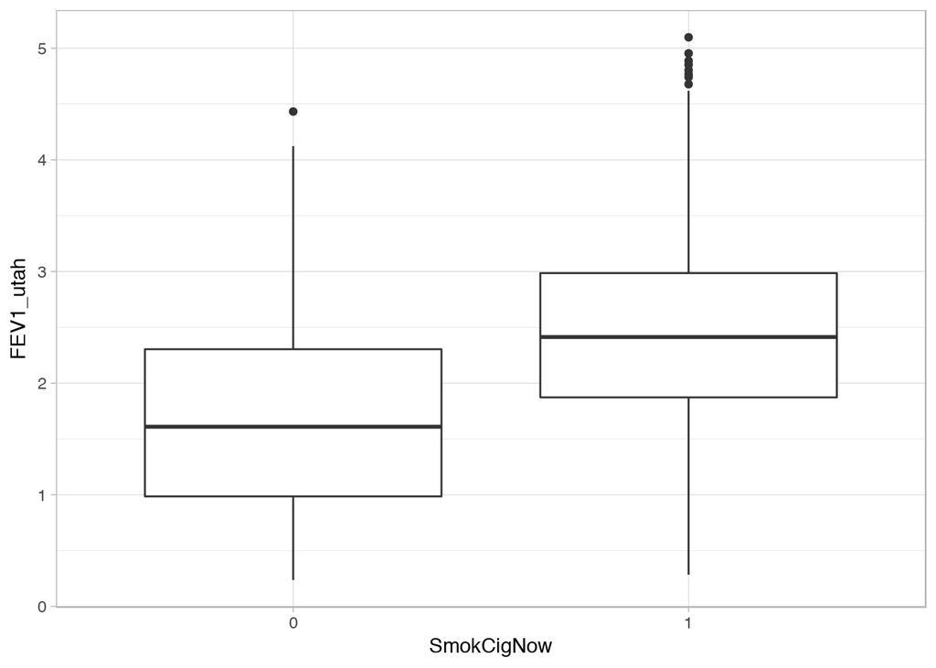

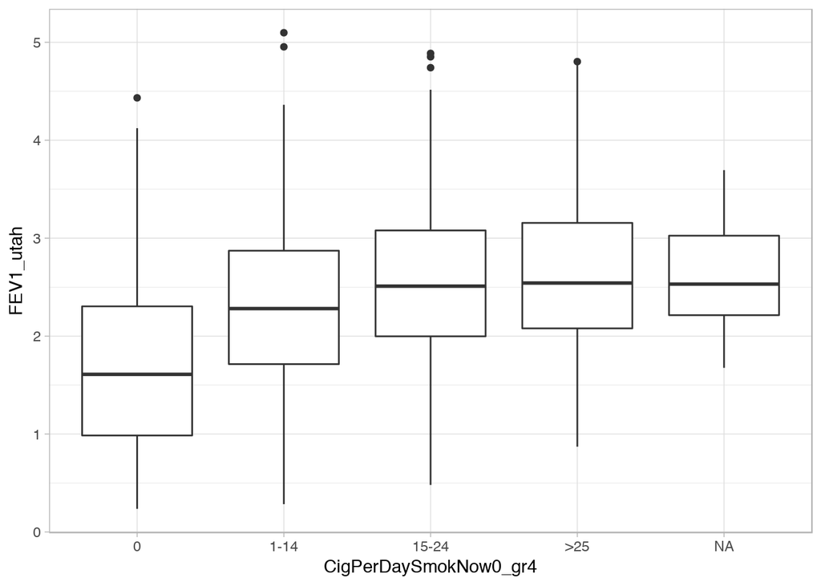

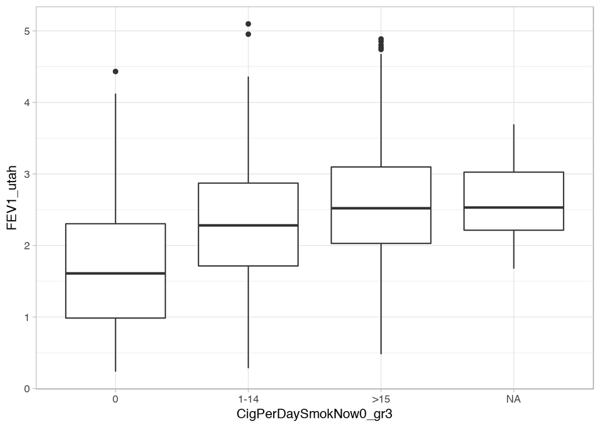

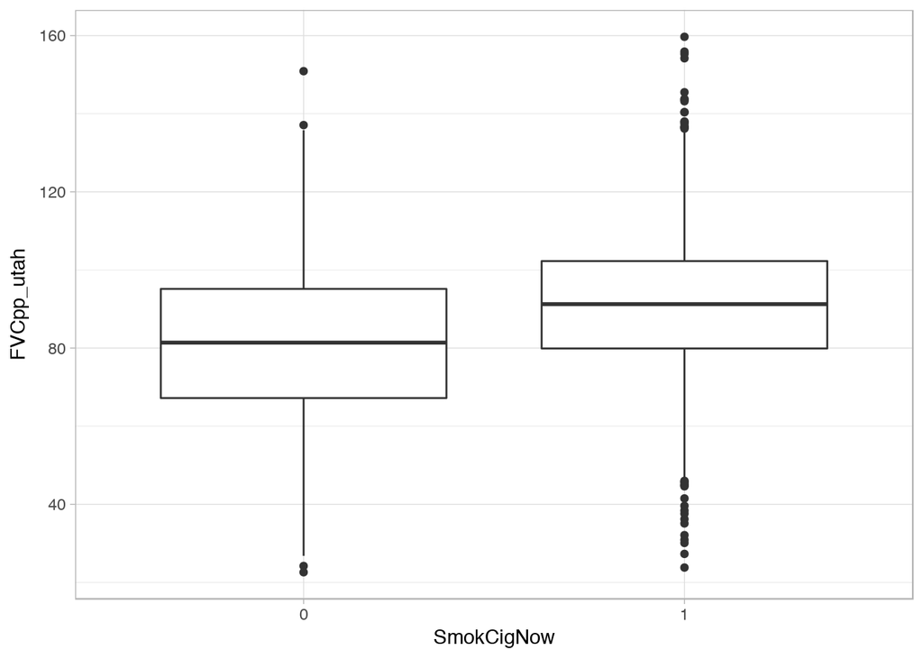

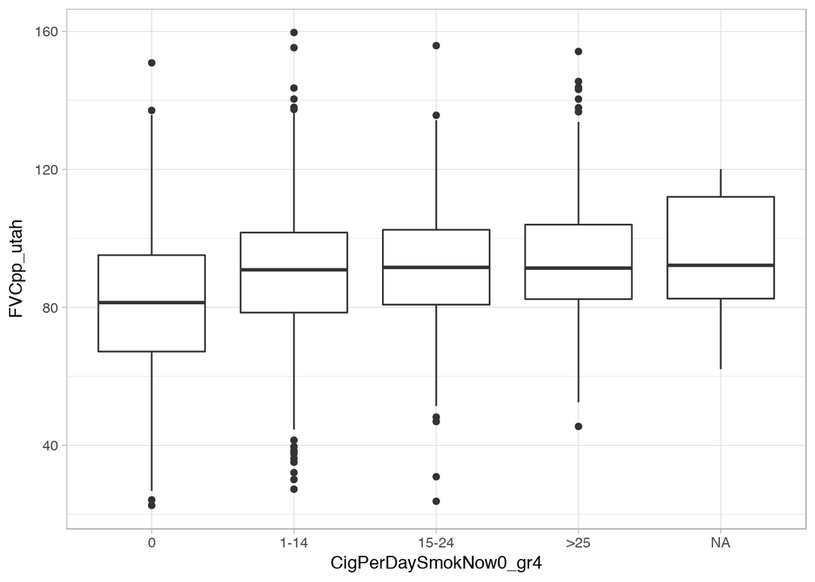

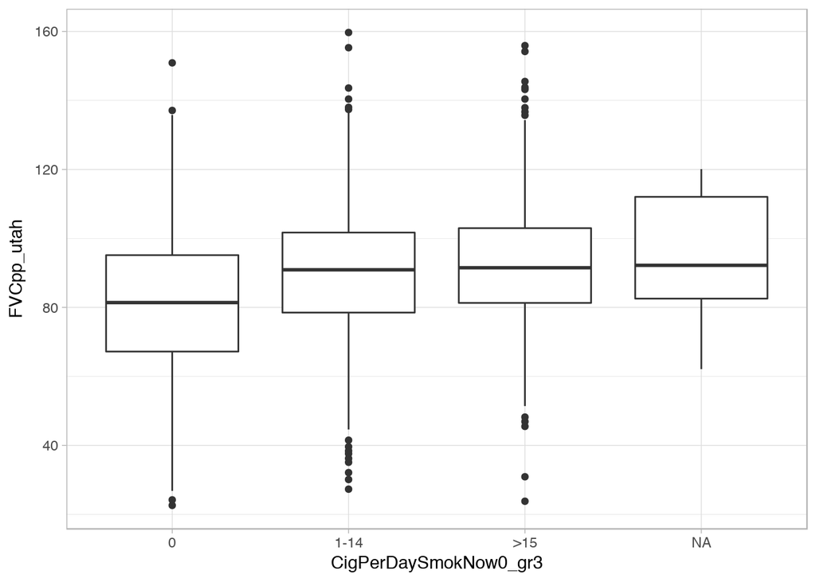

[9 more figures not shown]

### 3.3.3 Group 3 vs. 4

```r
with(filter(phen, CigPerDaySmokNow0_gr4 %in% c(">25", "15-24")),
  leveneTest(FEV1_FVC_utah, CigPerDaySmokNow0_gr4))
```

```
Levene's Test for Homogeneity of Variance (center = median)
        Df F value  Pr(>F)
group    1  3.4379 0.06393 .
      1360
---
Signif. codes:  0 '***' 0.001 '**' 0.01 '*' 0.05 '.' 0.1 ' ' 1
```

| trait | comparison | Fstat | pval |
| --- | --- | --- | --- |
| FEV1_FVC_utah | 3 vs 4 | 3.43790209 | 0.06393292 |
| FVCpp_utah | 3 vs 4 | 2.16679595 | 0.14125114 |
| TLCpp_race_adjusted | 3 vs 4 | 1.45743990 | 0.22756323 |
| FEV1_utah | 3 vs 4 | 0.78579975 | 0.37552994 |
| FEV1pp_utah | 3 vs 4 | 0.48930615 | 0.48435660 |
| FVC_utah | 3 vs 4 | 0.17213191 | 0.67828945 |
| log_pctEmph_Slicer | 3 vs 4 | 0.07657721 | 0.78204054 |

### 3.3.4 Group 2 vs. 3

| trait | comparison | Fstat | pval |
| --- | --- | --- | --- |
| FEV1_FVC_utah | 2 vs 3 | 15.40764627 | 0.0000893492 |
| FEV1pp_utah | 2 vs 3 | 11.66787762 | 0.0006476464 |
| FVCpp_utah | 2 vs 3 | 6.74673733 | 0.0094557051 |
| log_pctEmph_Slicer | 2 vs 3 | 4.00340744 | 0.0455577203 |
| TLCpp_race_adjusted | 2 vs 3 | 2.69184493 | 0.1010187312 |
| FEV1_utah | 2 vs 3 | 2.67756215 | 0.1019171013 |
| FVC_utah | 2 vs 3 | 0.07101404 | 0.7898914584 |

### 3.3.5 LRT on models smk0: 2 vs 3 levels

```
Linear mixed model fit by REML ['merModLmerTest']
Formula: FEV1_FVC_utah ~ Age_Enroll + Age_Enroll2 + gender + SmokCigNow +
    acs_global + (1 | ccenter) + Duration_Smoking + log_CigPerDaySmokAvg +
    (0 + dummy(SmokCigNowRev) | rsid)
   Data: phen2
REML criterion at convergence: -4613.426
Random effects:
 Groups   Name                 Std.Dev.
 rsid     dummy(SmokCigNowRev) 0.12868
 ccenter  (Intercept)          0.02224
 Residual                      0.10708
Number of obs: 3253, groups:  rsid, 3253; ccenter, 21
Fixed Effects:
         (Intercept)            Age_Enroll           Age_Enroll2
           1.041e+00            -5.582e-03            -6.677e-05
             gender2           SmokCigNow1            acs_global
           1.482e-02             7.301e-02            -1.549e-02
    Duration_Smoking  log_CigPerDaySmokAvg
          -1.450e-03            -2.563e-03
```

```
Linear mixed model fit by REML ['lmerMod']
Formula: FEV1_FVC_utah ~ Age_Enroll + Age_Enroll2 + gender + SmokCigNow +
    acs_global + (1 | ccenter) + Duration_Smoking + log_CigPerDaySmokAvg +
    (0 + dummy(CigPerDaySmokNow0Rev_gr3) | rsid)
   Data: phen2
REML criterion at convergence: NA
Random effects:
 Groups   Name                                Std.Dev. Corr
 rsid     dummy(CigPerDaySmokNow0Rev_gr3)1-14 0.06069
          dummy(CigPerDaySmokNow0Rev_gr3)0    0.13575  0.00
 ccenter  (Intercept)                         0.02081
 Residual                                     0.09855
Number of obs: 3253, groups:  rsid, 3253; ccenter, 21
Fixed Effects:
         (Intercept)            Age_Enroll           Age_Enroll2
           1.031e+00            -5.419e-03            -7.228e-05
             gender2           SmokCigNow1            acs_global
           1.478e-02             7.630e-02            -1.425e-02
    Duration_Smoking  log_CigPerDaySmokAvg
          -1.554e-03            -1.711e-03
```

```r
loglik_null <- logLikNum(mod_null)
loglik_alt <- logLikNum(mod_alt)
stat <- 2 * (loglik_alt - loglik_null)

(pval <- pchisq(stat, df = 1, lower = FALSE))
```

```
[1] 1.642485e-08
```

| trait | comparison | Chisq | pval |
| --- | --- | --- | --- |
| FEV1_FVC_utah | LRT: smk0_2 vs smk0_3 | 31.8770245 | 1.642485e-08 |
| FEV1pp_utah | LRT: smk0_2 vs smk0_3 | 11.6866853 | 6.294894e-04 |
| FVCpp_utah | LRT: smk0_2 vs smk0_3 | 7.3618328 | 6.662285e-03 |
| log_pctEmph_Slicer | LRT: smk0_2 vs smk0_3 | 5.7612464 | 1.638345e-02 |
| FEV1_utah | LRT: smk0_2 vs smk0_3 | 2.7917507 | 9.475066e-02 |
| TLCpp_race_adjusted | LRT: smk0_2 vs smk0_3 | 2.2498755 | 1.336252e-01 |
| FVC_utah | LRT: smk0_2 vs smk0_3 | 0.3477914 | 5.553660e-01 |

## 3.4 `SmokCigNow` vs. `CigPerDaySmokNow0_gr3`

```
Linear mixed model fit by REML ['lmerMod']
Formula: FEV1_FVC_utah ~ Age_Enroll + Age_Enroll2 + gender + SmokCigNow +
    acs_global + (1 | ccenter) + Duration_Smoking + log_CigPerDaySmokAvg +
    (0 + dummy(CigPerDaySmokNow0Rev_gr3) | rsid)
   Data: phen2
REML criterion at convergence: NA
Random effects:
 Groups   Name                                Std.Dev. Corr
 rsid     dummy(CigPerDaySmokNow0Rev_gr3)1-14 0.06069
          dummy(CigPerDaySmokNow0Rev_gr3)0    0.13575  0.00
 ccenter  (Intercept)                         0.02081
 Residual                                     0.09855
Number of obs: 3253, groups:  rsid, 3253; ccenter, 21
Fixed Effects:
         (Intercept)            Age_Enroll           Age_Enroll2
           1.031e+00            -5.419e-03            -7.228e-05
             gender2           SmokCigNow1            acs_global
           1.478e-02             7.630e-02            -1.425e-02
    Duration_Smoking  log_CigPerDaySmokAvg
          -1.554e-03            -1.711e-03
```

```
Linear mixed model fit by REML ['lmerMod']
Formula: FEV1_FVC_utah ~ Age_Enroll + Age_Enroll2 + gender + acs_global +
    (1 | ccenter) + Duration_Smoking + log_CigPerDaySmokAvg +
    (0 + dummy(CigPerDaySmokNow0Rev_gr3) | rsid) + CigPerDaySmokNow0_gr3
   Data: phen2
REML criterion at convergence: NA
Random effects:
 Groups   Name                                Std.Dev. Corr
 rsid     dummy(CigPerDaySmokNow0Rev_gr3)1-14 0.05944
          dummy(CigPerDaySmokNow0Rev_gr3)0    0.13620  0.00
 ccenter  (Intercept)                         0.02020
 Residual                                     0.09812
Number of obs: 3253, groups:  rsid, 3253; ccenter, 21
Fixed Effects:
              (Intercept)                 Age_Enroll
                1.053e+00                 -5.319e-03
              Age_Enroll2                    gender2
               -7.582e-05                  1.652e-02
               acs_global           Duration_Smoking
               -8.283e-03                 -1.558e-03
     log_CigPerDaySmokAvg  CigPerDaySmokNow0_gr31-14
               -1.305e-02                  6.034e-02
 CigPerDaySmokNow0_gr3>15
                8.769e-02
```

```r
loglik_null <- logLikNum(mod_null)
loglik_alt <- logLikNum(mod_alt)
stat <- 2 * (loglik_alt - loglik_null)

(pval <- pchisq(stat, df = 1, lower = FALSE))
```

```
[1] 4.73716e-07
```

| trait | comparison | Chisq | pval |
| --- | --- | --- | --- |
| FEV1_FVC_utah | LRT: SmokCigNow vs CigPerDaySmokNow0_gr3 | 25.367981 | 4.737160e-07 |
| FEV1pp_utah | LRT: SmokCigNow vs CigPerDaySmokNow0_gr3 | 22.876336 | 1.727658e-06 |
| log_pctEmph_Slicer | LRT: SmokCigNow vs CigPerDaySmokNow0_gr3 | 19.887345 | 8.214228e-06 |
| FEV1_utah | LRT: SmokCigNow vs CigPerDaySmokNow0_gr3 | 19.644245 | 9.328385e-06 |
| FVCpp_utah | LRT: SmokCigNow vs CigPerDaySmokNow0_gr3 | 4.983883 | 2.558450e-02 |
| TLCpp_race_adjusted | LRT: SmokCigNow vs CigPerDaySmokNow0_gr3 | 4.983263 | 2.559367e-02 |
| FVC_utah | LRT: SmokCigNow vs CigPerDaySmokNow0_gr3 | 1.160764 | 2.813071e-01 |

## 3.5 `Duration_Smoking * CigPerDaySmokNow0_gr3`

```
Linear mixed model fit by REML ['lmerMod']
Formula: FEV1_FVC_utah ~ Age_Enroll + Age_Enroll2 + gender + acs_global +
    (1 | ccenter) + Duration_Smoking + log_CigPerDaySmokAvg +
    CigPerDaySmokNow0_gr3 + (0 + dummy(CigPerDaySmokNow0Rev_gr3) |
    rsid)
   Data: phen2
REML criterion at convergence: NA
Random effects:
 Groups   Name                                Std.Dev. Corr
 rsid     dummy(CigPerDaySmokNow0Rev_gr3)1-14 0.05944
          dummy(CigPerDaySmokNow0Rev_gr3)0    0.13620  0.00
 ccenter  (Intercept)                         0.02020
 Residual                                     0.09812
Number of obs: 3253, groups:  rsid, 3253; ccenter, 21
Fixed Effects:
              (Intercept)                 Age_Enroll
                1.053e+00                 -5.319e-03
              Age_Enroll2                    gender2
               -7.582e-05                  1.652e-02
               acs_global           Duration_Smoking
               -8.283e-03                 -1.558e-03
     log_CigPerDaySmokAvg  CigPerDaySmokNow0_gr31-14
               -1.305e-02                  6.034e-02
 CigPerDaySmokNow0_gr3>15
                8.769e-02
```

```
Linear mixed model fit by REML ['lmerMod']
Formula: FEV1_FVC_utah ~ Age_Enroll + Age_Enroll2 + gender + acs_global +
    (1 | ccenter) + Duration_Smoking + log_CigPerDaySmokAvg +
    CigPerDaySmokNow0_gr3 + (0 + dummy(CigPerDaySmokNow0Rev_gr3) |
    rsid) + Duration_Smoking:CigPerDaySmokNow0_gr3
   Data: phen2
REML criterion at convergence: NA
Random effects:
 Groups   Name                                Std.Dev. Corr
 rsid     dummy(CigPerDaySmokNow0Rev_gr3)1-14 0.05925
          dummy(CigPerDaySmokNow0Rev_gr3)0    0.13493  0.00
 ccenter  (Intercept)                         0.01991
 Residual                                     0.09817
Number of obs: 3253, groups:  rsid, 3253; ccenter, 21
Fixed Effects:
                               (Intercept)
                                 1.121e+00
                                Age_Enroll
                                -5.408e-03
                               Age_Enroll2
                                -5.853e-05
                                   gender2
                                 1.634e-02
                                acs_global
                                -7.940e-03
                          Duration_Smoking
                                -3.336e-03
                      log_CigPerDaySmokAvg
                                -1.392e-02
                 CigPerDaySmokNow0_gr31-14
                                -1.879e-02
                  CigPerDaySmokNow0_gr3>15
                                 1.108e-02
Duration_Smoking:CigPerDaySmokNow0_gr31-14
                                 2.244e-03
 Duration_Smoking:CigPerDaySmokNow0_gr3>15
                                 2.187e-03
```

```r
loglik_null <- logLikNum(mod_null)
loglik_alt <- logLikNum(mod_alt)
stat <- 2 * (loglik_alt - loglik_null)

(pval <- pchisq(stat, df = 2, lower = FALSE))
```

```
[1] 1
```

[output not shown]

## 3.6 `SmokCigarNow`

| trait | comparison | Chisq | pval |
| --- | --- | --- | --- |
| FEV1pp_utah | LRT: adding SmokCigarNow | 52.247581 | 4.892618e-13 |
| FVCpp_utah | LRT: adding SmokCigarNow | 41.974687 | 9.246264e-11 |
| TLCpp_race_adjusted | LRT: adding SmokCigarNow | 39.658444 | 3.024940e-10 |
| FEV1_utah | LRT: adding SmokCigarNow | 18.236554 | 1.950983e-05 |
| log_pctEmph_Slicer | LRT: adding SmokCigarNow | 14.362082 | 1.508088e-04 |
| FVC_utah | LRT: adding SmokCigarNow | 7.564294 | 5.953597e-03 |
| FEV1_FVC_utah | LRT: adding SmokCigarNow | -1.541672 | 1.000000e+00 |

## 3.7 `(1|SchoolCompleted)`

| trait | comparison | Chisq | pval |
| --- | --- | --- | --- |
| FEV1_utah | LRT: adding (1\|SchoolCompleted) | 1.159404e+01 | 0.0006616335 |
| FVC_utah | LRT: adding (1\|SchoolCompleted) | 9.622519e+00 | 0.0019220588 |
| FEV1pp_utah | LRT: adding (1\|SchoolCompleted) | 6.418061e+00 | 0.0112965465 |
| FVCpp_utah | LRT: adding (1\|SchoolCompleted) | 4.203604e+00 | 0.0403381569 |
| log_pctEmph_Slicer | LRT: adding (1\|SchoolCompleted) | 1.388381e+00 | 0.2386786949 |
| FEV1_FVC_utah | LRT: adding (1\|SchoolCompleted) | 2.422197e-01 | 0.6226074879 |
| TLCpp_race_adjusted | LRT: adding (1\|SchoolCompleted) | 2.182787e-11 | 0.9999962723 |

## 3.8 `SchoolCompleted_gr2`

| trait | comparison | Chisq | pval |
| --- | --- | --- | --- |
| FVCpp_utah | LRT: adding SchoolCompleted_gr2 | 8.431874 | 0.003687002 |
| FEV1pp_utah | LRT: adding SchoolCompleted_gr2 | 7.352075 | 0.006698539 |
| FVC_utah | LRT: adding SchoolCompleted_gr2 | 6.056889 | 0.013852148 |
| FEV1_utah | LRT: adding SchoolCompleted_gr2 | 4.244905 | 0.039368261 |
| TLCpp_race_adjusted | LRT: adding SchoolCompleted_gr2 | 1.326832 | 0.249369545 |
| log_pctEmph_Slicer | LRT: adding SchoolCompleted_gr2 | 1.258547 | 0.261926228 |
| FEV1_FVC_utah | LRT: adding SchoolCompleted_gr2 | -8.556326 | 1.000000000 |

| trait | comparison | Chisq | pval |
| --- | --- | --- | --- |
| FVCpp_utah | LRT: adding SchoolCompleted_gr3 | 14.0114798 | 0.0009066629 |
| FEV1pp_utah | LRT: adding SchoolCompleted_gr3 | 12.0269599 | 0.0024455629 |
| TLCpp_race_adjusted | LRT: adding SchoolCompleted_gr3 | 4.9280988 | 0.0850896922 |
| FVC_utah | LRT: adding SchoolCompleted_gr3 | 4.1570056 | 0.1251173990 |
| FEV1_utah | LRT: adding SchoolCompleted_gr3 | 1.2836255 | 0.5263374478 |
| log_pctEmph_Slicer | LRT: adding SchoolCompleted_gr3 | 0.5437922 | 0.7619334029 |
| FEV1_FVC_utah | LRT: adding SchoolCompleted_gr3 | -14.6467860 | 1.0000000000 |

## 3.10 Previous vs. Current model

| trait | comparison | Chisq | df | pval |
| --- | --- | --- | --- | --- |
| FEV1_FVC_utah | LRT: Previous vs Current | 62.767223 | 3 | 1.506046e-13 |
| FEV1pp_utah | LRT: Previous vs Current | 55.211592 | 3 | 6.188324e-12 |
| FEV1_utah | LRT: Previous vs Current | 38.488821 | 3 | 2.227099e-08 |
| log_pctEmph_Slicer | LRT: Previous vs Current | 37.568597 | 3 | 3.487913e-08 |
| FVCpp_utah | LRT: Previous vs Current | 21.397172 | 3 | 8.705938e-05 |
| TLCpp_race_adjusted | LRT: Previous vs Current | 21.094040 | 3 | 1.006465e-04 |
| FVC_utah | LRT: Previous vs Current | 3.372131 | 3 | 3.377289e-01 |